# Title

#### Skin Cancer

- Whether respondents have ever been told they have skin cancer
- Possible values: Yes, No

[figure not shown]

```python
for c in categoricals:
    display(df[c].value_counts().plot(kind='bar', xlabel=c, ylabel='Count', rot=0))
```

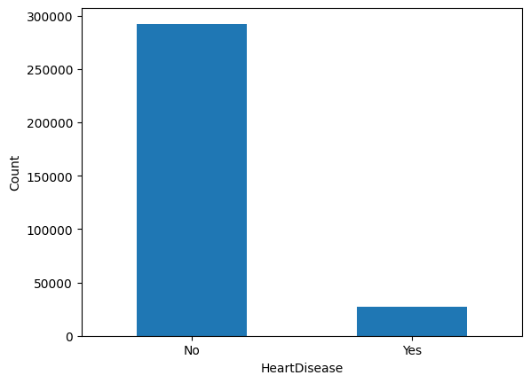

```python
df['HeartDisease'].value_counts().plot(kind='bar', xlabel='HeartDisease', ylabel='Count', rot=0);
```

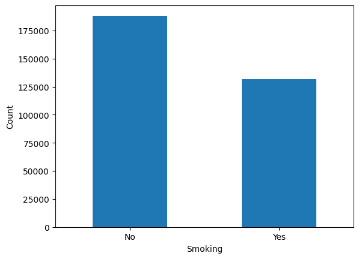

```python
df['Smoking'].value_counts().plot(kind='bar', xlabel='Smoking', ylabel='Count', rot=0);
```

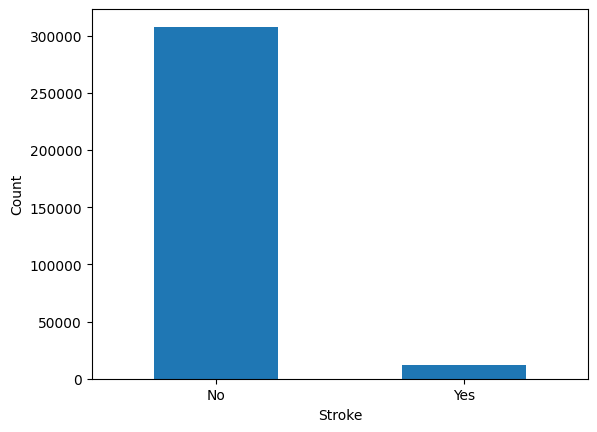

```python
df['Stroke'].value_counts().plot(kind='bar', xlabel='Stroke', ylabel='Count', rot=0);
```

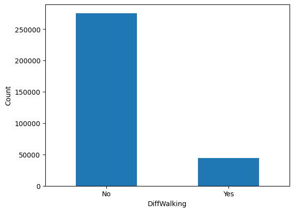

```python
df['DiffWalking'].value_counts().plot(kind='bar', xlabel='DiffWalking', ylabel='Count', rot=0);
```

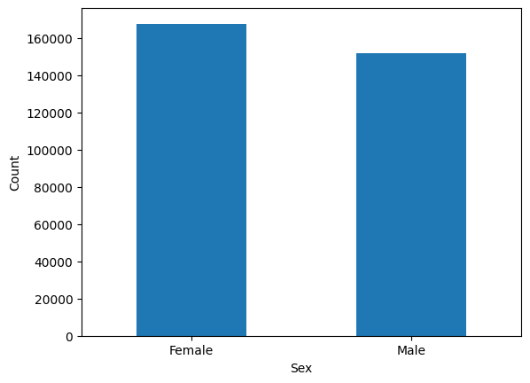

```python
df['Sex'].value_counts().plot(kind='bar', xlabel='Sex', ylabel='Count', rot=0);
```

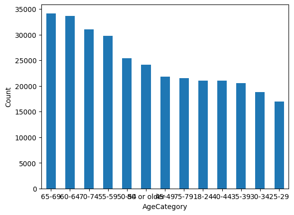

```python
df['AgeCategory'].value_counts().plot(kind='bar', xlabel='AgeCategory', ylabel='Count', rot=0);
```

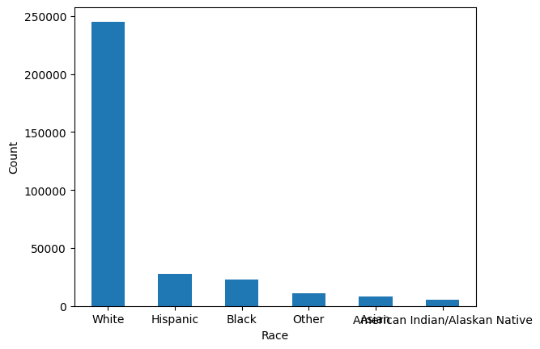

```python
df['Race'].value_counts().plot(kind='bar', xlabel='Race', ylabel='Count', rot=0);
```

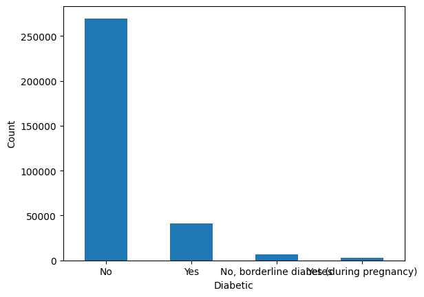

```python
df['Diabetic'].value_counts().plot(kind='bar', xlabel='Diabetic', ylabel='Count', rot=0);
```

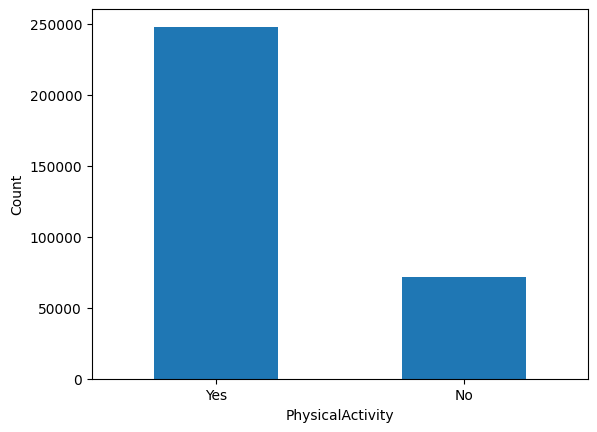

```python
df['PhysicalActivity'].value_counts().plot(kind='bar', xlabel='PhysicalActivity', ylabel='Count', rot=0);
```

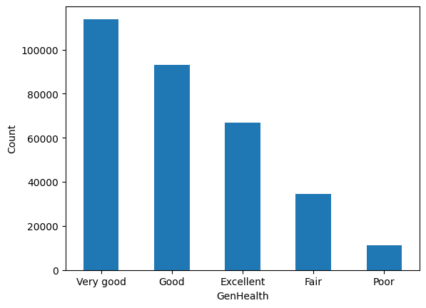

```python
df['GenHealth'].value_counts().plot(kind='bar', xlabel='GenHealth', ylabel='Count', rot=0);
```

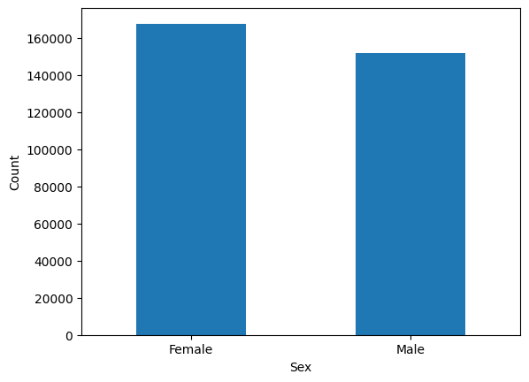

```python
df['Sex'].value_counts().plot(kind='bar', xlabel='Sex', ylabel='Count', rot=0);
```

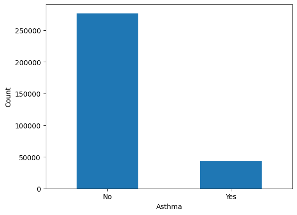

```python
df['Asthma'].value_counts().plot(kind='bar', xlabel='Asthma', ylabel='Count', rot=0);
```

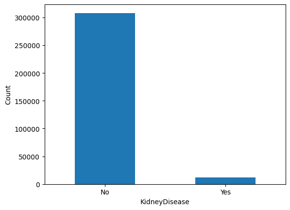

```python
df['KidneyDisease'].value_counts().plot(kind='bar', xlabel='KidneyDisease', ylabel='Count', rot=0);
```

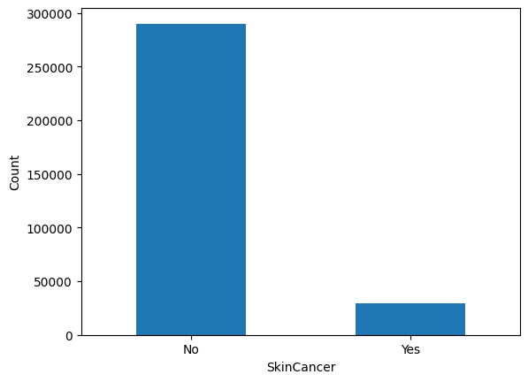

```python
df['SkinCancer'].value_counts().plot(kind='bar', xlabel='SkinCancer', ylabel='Count', rot=0);
```

It doesn't make much sense to include our categorical variables in the correlation matrix below (even after encoding) as they mostly aren't consisting of ordered scales, instead they are almost all binary valued.

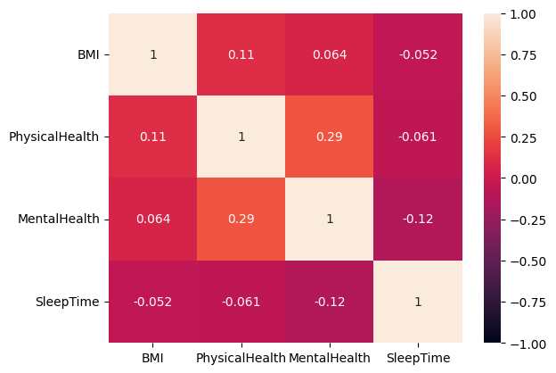

```python
sns.heatmap(df.corr(numeric_only=True), vmin=-1, vmax=1, center=0, annot=True, cmap='rocket');
```

Below we can see relations between numerical data and the distributions each type of data. For BMI we see a bit of a skewed normal distribution, but for the rest there appears to be some discrete aspect of separation to the data values, especially with sleep time. We also can't really see much of a clear linear relationship in the scatter plots which matches with the low correlation that we see in the correlation matrix.

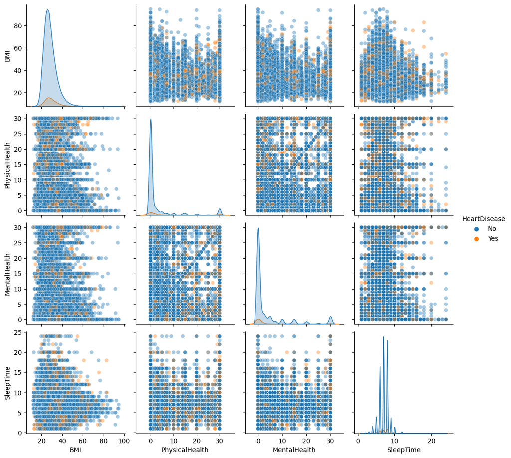

```python
sns.pairplot(df, hue='HeartDisease', plot_kws=dict(alpha=0.4));
```

See below for the discrete integer nature of the specified variables for confirmation of what we noticed above with the histograms

```python
df['SleepTime'].unique() # see the discrete integer values
```

```
array([ 5.,  7.,  8.,  6., 12.,  4.,  9., 10., 15.,  3.,  2.,  1., 16.,
       18., 14., 20., 11., 13., 17., 24., 19., 21., 22., 23.])
```

```python
df['MentalHealth'].unique()
```

```
array([30.,  0.,  2.,  5., 15.,  8.,  4.,  3., 10., 14., 20.,  1.,  7.,
       24.,  9., 28., 16., 12.,  6., 25., 17., 18., 21., 29., 22., 13.,
       23., 27., 26., 11., 19.])
```

```python
df['PhysicalHealth'].unique()
```

```
array([ 3.,  0., 20., 28.,  6., 15.,  5., 30.,  7.,  1.,  2., 21.,  4.,
       10., 14., 18.,  8., 25., 16., 29., 27., 17., 24., 12., 23., 26.,
       22., 19.,  9., 13., 11.])
```

With a wide variety of features such as pre-existing health conditions, and general lifestyle information such as level of physical activity, or drinking alcohol, this data set provides us with a large amount of information to perform a binary classification on the presence of heart disease in an individual.

Some potential biases arise however when considering the source of the data, as this is data collected from a voluntary response phone poll, which means that there could be a significant difference between people who answer phone polls and people who don't. Additionally, the data collected from the poll could also have inaccuracies, as it is possible people lie or exaggerate about their lifestyle habits such as exercise or alcohol consumption.

Aside from any potential biases from the collection of the data, this data set provides a great opportunity to try and predict the likelihood of heart disease in an individual based on their pre-existing health conditions and their broad lifestyle habits.

## Data Preprocessing

```python
encode = lambda unique: dict( zip( sorted(unique), range(len(unique)) ) )

# encode( df[categoricals[0]].unique() )
encoding = {'GenHealth': {'Poor': 0, 'Fair': 1, 'Good': 2, 'Very good': 3, 'Excellent': 4}}

# perform genhealth encoding manually since no sorting function
df_encode = df.copy()
for c in categoricals:
  if c != 'GenHealth': encoding[c] = encode(df[c].unique()) # save to encoding
  df_encode[c] = df.apply( lambda row: encoding[c][row[c]], axis=1) # perform encoding

encoding
```

```
{'GenHealth': {'Poor': 0,
  'Fair': 1,
  'Good': 2,
  'Very good': 3,
  'Excellent': 4},
 'HeartDisease': {'No': 0, 'Yes': 1},
 'Smoking': {'No': 0, 'Yes': 1},
 'AlcoholDrinking': {'No': 0, 'Yes': 1},
 'Stroke': {'No': 0, 'Yes': 1},
 'DiffWalking': {'No': 0, 'Yes': 1},
 'Sex': {'Female': 0, 'Male': 1},
 'AgeCategory': {'18-24': 0,
  '25-29': 1,
  '30-34': 2,
  '35-39': 3,
  '40-44': 4,
  '45-49': 5,
  '50-54': 6,
  '55-59': 7,
  '60-64': 8,
  '65-69': 9,
  '70-74': 10,
  '75-79': 11,
  '80 or older': 12},
 'Race': {'American Indian/Alaskan Native': 0,
  'Asian': 1,
  'Black': 2,
  'Hispanic': 3,
  'Other': 4,
  'White': 5},
 'Diabetic': {'No': 0,
  'No, borderline diabetes': 1,
  'Yes': 2,
  'Yes (during pregnancy)': 3},
 'PhysicalActivity': {'No': 0, 'Yes': 1},
 'Asthma': {'No': 0, 'Yes': 1},
 'KidneyDisease': {'No': 0, 'Yes': 1},
 'SkinCancer': {'No': 0, 'Yes': 1}}
```

We will be using one-hot encoding for race, as race is not a scale nor is it binary.

```python
df_encode['American Indian/Alaskan Native'] = df_encode.apply( lambda x: int(x.Race == 0), axis=1)
df_encode['Asian'] = df_encode.apply( lambda x: int(x.Race == 1), axis=1)
df_encode['Black'] = df_encode.apply( lambda x: int(x.Race == 2), axis=1)
df_encode['Hispanic'] = df_encode.apply( lambda x: int(x.Race == 3), axis=1)
df_encode['White'] = df_encode.apply( lambda x: int(x.Race == 5), axis=1)
df_encode['Other Race'] = df_encode.apply( lambda x: int(x.Race == 4), axis=1)
```

```python
# uncomment to sanity check results
# df_encode_races = df_encode[['Race', 'Asian', 'Black', 'Hispanic', 'American Indian/Alaskan Native', 'White', 'Other Race']]
df_encode = df_encode.drop(columns=['Race'])
```

Now that our races are encoded, we will check the distribution of races as percentages.

```python
races = df_encode[['Asian', 'Black', 'Hispanic', 'American Indian/Alaskan Native', 'White', 'Other Race']].sum()
print(races / races.sum() * 100)
```

```
Asian                              2.522866
Black                              7.173033
Hispanic                           8.582373
American Indian/Alaskan Native     1.626667
White                             76.677872
Other Race                         3.417189
dtype: float64
```

We can see that the most common race in our dataset is White at 76%, followed by Hispanic at 8.5%, and Black at 7.1%. This presents a possible source of bias in our model, as our model will likely be more effective at predicting heart disease in white people than other racial groups due to the sample size if race ends up being an important factor.

```python
df_num = df.select_dtypes(include=['float64'])

from sklearn.preprocessing import MinMaxScaler

scaler = MinMaxScaler()
df_num_norm = scaler.fit(df_num).transform(df_num)
df_num_norm = pd.DataFrame(df_num_norm, columns=df_num.columns, index=df_num.index)
df_num_norm.head()
```

|  | BMI | PhysicalHealth | MentalHealth | SleepTime |
| --- | --- | --- | --- | --- |
| 0 | 0.055294 | 0.100000 | 1.0 | 0.173913 |
| 1 | 0.100447 | 0.000000 | 0.0 | 0.260870 |
| 2 | 0.175782 | 0.666667 | 1.0 | 0.304348 |
| 3 | 0.147169 | 0.000000 | 0.0 | 0.217391 |
| 4 | 0.141132 | 0.933333 | 0.0 | 0.304348 |

Now we need to add this data back into our full data set.

```python
numericals = df.select_dtypes(include=['float64']).columns
dft = df_encode.copy()
for colname in numericals:
    dft[colname] = df_num_norm[colname]
```

Now, `dft` contains our data with `Race` one hot encoded, other categorical variables label encoded, and the numerical features min max normalized. We can now begin building our model.

## Model Building

Before we train a model, we first need to split our data into train and test data sets.

```python
from sklearn.model_selection import train_test_split

X = dft.drop(columns=['HeartDisease'])
y = dft['HeartDisease']

X_train, X_test, y_train, y_test = train_test_split(X, y, test_size=0.2, random_state=42)
```

```python
dims = X_train.shape[1]
```

```python
from keras.models import Sequential
from keras.layers import Dense
```

```python
model = Sequential()
model.add(Dense(units=4, activation='tanh', input_dim=dims,  ))
model.add(Dense(units=4, activation='relu', input_dim=dims,))
model.add(Dense(units=1, activation='sigmoid', input_dim=dims,  ))
```

```python
model.compile(optimizer = 'rmsprop', loss = 'binary_crossentropy')
history = model.fit(X_train.astype('float'), y_train, batch_size = 1, epochs = 10)
```

## Model Evaluation

```python
yhat_train = model.predict(X_train)
yhat_train = [ 1 if y>=0.5 else 0 for y in yhat_train ]
```

Here we threshold the predictions from the sigmoid percent likelihood of heart disease to a binary decision on presence of heart disease with a threshold of 0.5

```python
yhat_test = model.predict(X_test)
yhat_test = [ 1 if y>=0.5 else 0 for y in yhat_test ]
```

```python
from sklearn.metrics import classification_report
```

```python
print(classification_report(y_train.values.tolist(), yhat_train))
```

```
              precision    recall  f1-score   support

           0       0.92      0.99      0.96    234055
           1       0.51      0.09      0.16     21781

    accuracy                           0.92    255836
   macro avg       0.71      0.54      0.56    255836
weighted avg       0.89      0.92      0.89    255836
```

The training data predictions has a ~92% accuracy

```python
print(classification_report(y_test.values.tolist(), yhat_test))
```

```
              precision    recall  f1-score   support

           0       0.92      0.99      0.95     58367
           1       0.49      0.09      0.15      5592

    accuracy                           0.91     63959
   macro avg       0.71      0.54      0.55     63959
weighted avg       0.88      0.91      0.88     63959
```

The testing data predictions has a 91% accuracy

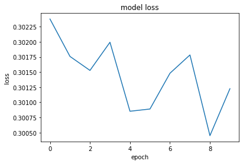

```python
from matplotlib import pyplot as plt
plt.plot(history.history['loss'])
plt.title('model loss')
plt.xlabel('epoch')
plt.ylabel('loss')
plt.show()
```

The final iteration of the model is not the absolute minima in the fitting graph as seen here. It reached an absolute minima in epoch 8, and rose to a loss value ~0.30125 in epoch 10. This could be a sign of the model epochs correcting for overfitting, resulting in a less accurate model for training data but without overfitting. Or this rise in loss could be explained by overtraining the model.